# Homework #1

Aleksander Molak

April 4, 2019

## Import required libraries

```r
library(foreign)    # read in SPSS craziness into eel-readable, sorry, R-readable format
library(ggplot2)    # get quality plots, baby!
library(dplyr)      # make your life easier :)
library(QuantPsyc)  # get standardized coefficients!
library(car)        # get vif to compute Variance Inflation Factor
library(effects)
library(rcompanion) # get R^2 for logit
library(lmtest)
library(vcd)
library(xtable)
library(pander)
library(stargazer)
```

## Load, transform and examine the data

```r
# Set working dir.
setwd('C:\\Users\\aleksander.molak\\Documents\\Personal\\Psych\\STATS_METHODS\\Hmwrk_1')

# Import the data
my_data <- read.spss("H1_dataset3.sav", to.data.frame=TRUE)

# Set `gender` type to factor
my_data$gender<-as.factor(my_data$gender)
```

#### View and examine the data

```r
# Eyeball the dataset
# View(my_data)

# Look at some interesting variables
my_data %>% count(behaviour)
```

```
## # A tibble: 2 x 2
##   behaviour        n
##   <fct>        <int>
## 1 nieuczestnik   107
## 2 uczestnik      186
```

```r
my_data %>% count(gender)
```

```
## # A tibble: 2 x 2
##   gender     n
##   <fct>  <int>
## 1 female   171
## 2 male     122
```

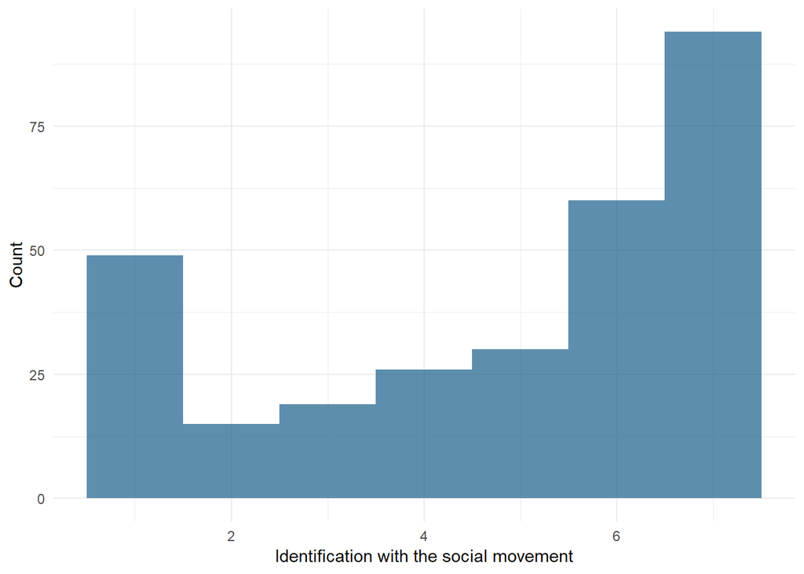

Figure 1. Histogram: Identification with The Social Movement.

```r
# Histogrm: ID with the socil mvmnt
ggplot(my_data, aes(ID)) + geom_histogram(bins=7, fill=color, alpha=.7) +
                           xlab('Identification with the social movement') +
                           ylab('Count') +
                           theme_minimal()
```

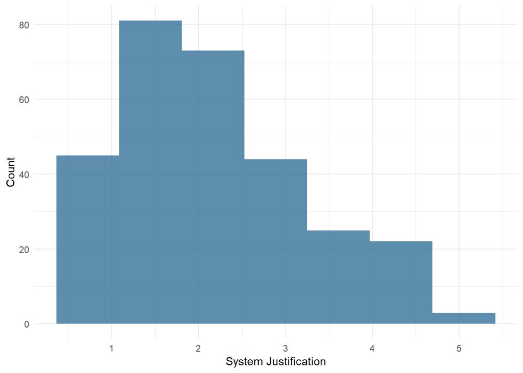

Figure 2. Histogram: System Justification.

```r
# Histogrm: System Justification
ggplot(my_data, aes(SJ)) + geom_histogram(bins=7, fill=color, alpha=.7) +
                           xlab('System Justification') +
                           ylab('Count') +
                           theme_minimal()
```

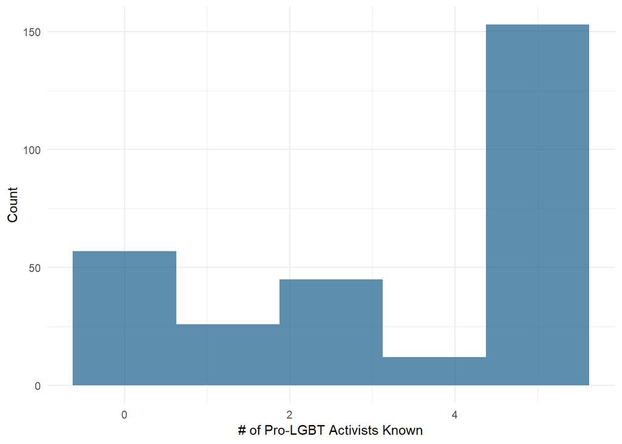

Figure 3. Histogram: Number of Pro-LGBT Activists a Respondent Knows.

```r
# Histogrm: Number of Pro-LGBT Activists a Respondent Knows
ggplot(my_data, aes(EMB1)) + geom_histogram(bins=5, fill=color, alpha=.7) +
                             xlab('# of Pro-LGBT Activists Known') +
                             ylab('Count') +
                             theme_minimal()
```

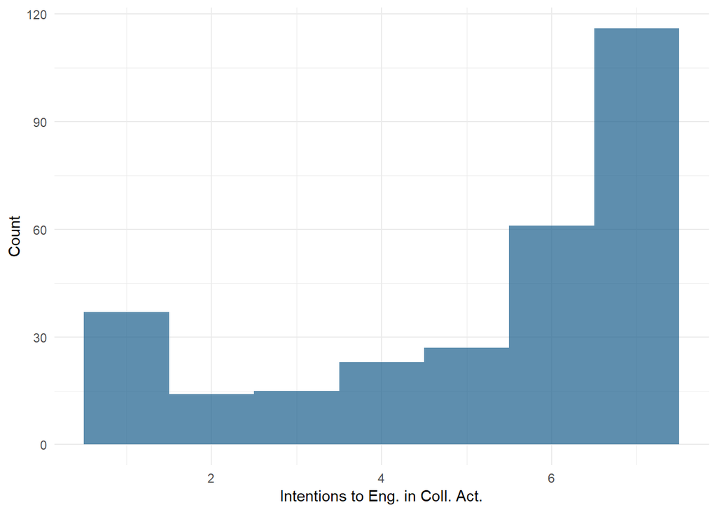

Figure 4. Histogram: Intentions to Engage in Collective Action.

```r
# Histogrm: Intentions to Engage in Collective Action
ggplot(my_data, aes(CA)) + geom_histogram(bins=7, fill=color, alpha=.7) +
                           xlab('Intentions to Eng. in Coll. Act.') +
                           ylab('Count') +
                           theme_minimal()
```

## Modelling 1: Linear Regression

### Inspect the data.

##### Are the relationships between collective action and its two potential predictors – system justification and identification with the social movement – linear? Provide scatterplots.

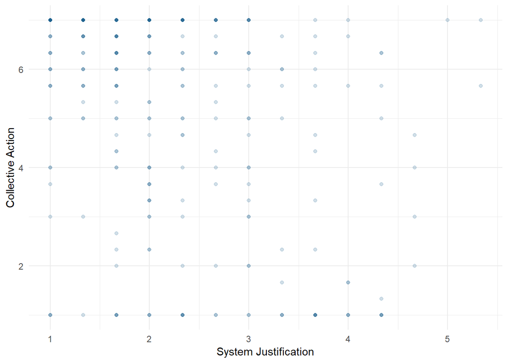

Figure 5. Relationship between System Justification and Collective Action.

```r
ggplot(my_data, aes(SJ, CA)) + geom_point(color=color, alpha=.2) +
                               xlab('System Justification') +
                               ylab('Collective Action') +
                               theme_minimal()
```

Based on the scatterplot, relationship between System Justification ($SJ$) and Collective Action ($CA$) does not look linear. Let’s fit local regression line using locally estimated scatterplot smoothing (loess) method to make sure if that’s the case.

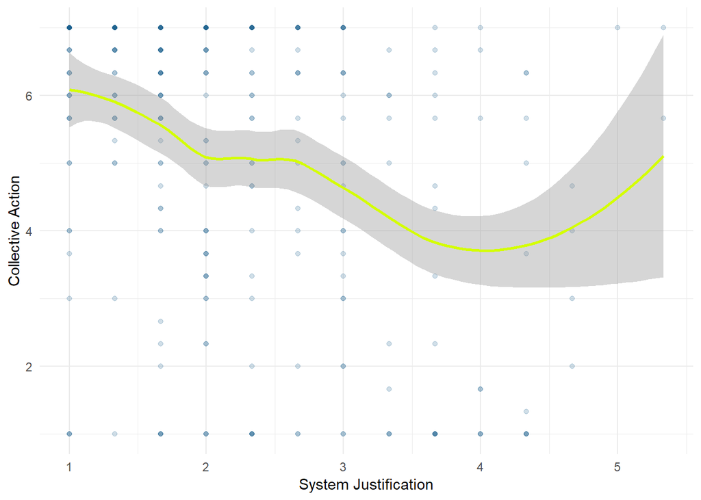

Figure 6. Relationship between System Justification and Collective Action with added LOESS regression line.

```r
ggplot(my_data, aes(SJ, CA)) + geom_point(color=color, alpha=.2) +
                               xlab('System Justification') +
                               ylab('Collective Action') +
                               geom_smooth(color=color2, method='loess') +
                               theme_minimal()
```

Loess line shows non-linear relationship. The relationship is neither linear nor perfectly quadratic. Nonetheless, based on visual inspection we can assume that adding linear and quadratic predictors to the model ($I(SJ^2)$) could model this relationship well. It’s also worth noticing that confidence intervals for high values of $SJ$ are broad and therefore the relationship between variables in this area of the scatterplot is not strongly unequivocal. This said, we can still expect that this data can be modelled successfully using linear model as the relationship for $SJ$ values between $1$ and $4$ is almost linear.

Let’s now examine realtionship between Identification with Social Movement ($ID$) and Collective Action ($CA$):

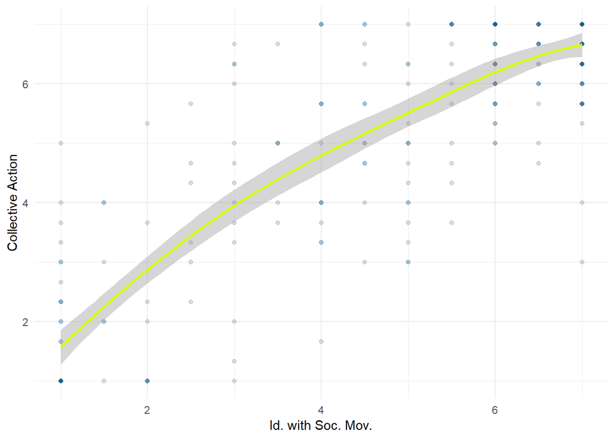

Figure 7. Relationship between Identification with Social Movement and Collective Action.

```r
ggplot(my_data, aes(ID, CA)) + geom_point(color=color, alpha=.2) +
                               xlab('Id. with Soc. Mov.') +
                               ylab('Collective Action') +
                               geom_smooth(color=color2, method='loess') +
                               theme_minimal()
```

The above relationship is almost perfectly linear. It is positive, which means that the stronger our participants identify themselves with social movement, the stronger are their intentions for collective action.

How about number of known activists ($EMB1$)?

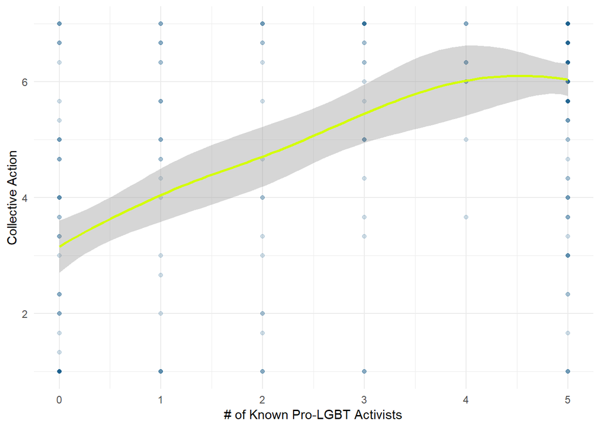

Figure 8. Relationship between Number of Known Pro-LGBT Activists and Collective Action.

```r
ggplot(my_data, aes(EMB1, CA)) + geom_point(color=color, alpha=.2) +
                                 xlab('# of Known Pro-LGBT Activists') +
                                 ylab('Collective Action') +
                                 geom_smooth(color=color2, method='loess') +
                                 theme_minimal()
```

This relationship also looks nicely linear! The more pro-LGBT activists our participants know, the stronger are their intentions for collective action.

### Regress collective action intentions on system justification (Model 1).

```r
# Build a model
model_1 <- lm(CA ~ SJ, my_data)
```

##### How much DV’s variance is explained by this model?

```r
summary(model_1)
```

```
##
## Call:
## lm(formula = CA ~ SJ, data = my_data)
##
## Residuals:
##     Min      1Q  Median      3Q     Max
## -5.0535 -1.3114  0.7745  1.4306  4.1620
##
## Coefficients:
##             Estimate Std. Error t value Pr(>|t|)
## (Intercept)   6.7955     0.2791  24.345  < 2e-16 ***
## SJ           -0.7420     0.1149  -6.457 4.47e-10 ***
## ---
## Signif. codes:  0 '***' 0.001 '**' 0.01 '*' 0.05 '.' 0.1 ' ' 1
##
## Residual standard error: 1.97 on 291 degrees of freedom
## Multiple R-squared:  0.1253, Adjusted R-squared:  0.1223
## F-statistic: 41.69 on 1 and 291 DF,  p-value: 4.471e-10
```

$R^2$ for this model equals $0.1253$, which means that model explains $12.53$% of variance. We can use $R^2$ here and not $R^2_{adj}$, because we have a model with just one predictor and therefore we don’t need to adjust for inflated $R^2$ caused by adding more predictors to the model.

##### Does the model fit data well, as expressed in its F statistic?

$F(1, 291) = 41.69, p<.00001$. Based on $F$ statistic we can say that at least one of predictors is related to $DV$ (at least one predictor’s coefficient is different from zero) (Hastie et al., 2009). In our case (model with just one predictor) $F$ statistic only confirms what we already knew based on $t$ statistic and its $p-value$: $SJ$ is significantly related to $CA$.

##### Is system justification a significant predictor of the DV?

Yes, it is. We can say this based on on $t$ statistic and its $p-value$.

##### Report the unstandardized and the standardized coefficient for system justification, a 95% CI for the unstandardized coefficient and a p-value.

```r
# Unstandardized coefficients
coef(model_1)
```

```
## (Intercept)          SJ
##   6.7955105  -0.7420328
```

```r
# Standardized coefficients
lm.beta(model_1)
```

```
##         SJ
## -0.3539947
```

```r
# Conf int
confint(model_1)
```

```
##                  2.5 %     97.5 %
## (Intercept)  6.2461311  7.3448899
## SJ          -0.9682181 -0.5158474
```

##### How may you interpret the relationship between the DV and its predictor?

Based on standardized coefficients we can say that moving one standard deviation up in $SJ$ is related to $-.35$ standard deviation drop in $CA$.

### Add identification with the social movement as an explanatory variable (Model 2).

```r
model_2 <- lm(CA ~ SJ + ID, my_data)
```

##### What is the relationship between collective action intentions and identification with the social movement?

```r
summary(model_2)
```

```
##
## Call:
## lm(formula = CA ~ SJ + ID, data = my_data)
##
## Residuals:
##     Min      1Q  Median      3Q     Max
## -3.4476 -0.6794 -0.0058  0.5119  3.0652
##
## Coefficients:
##             Estimate Std. Error t value Pr(>|t|)
## (Intercept)  1.55571    0.24332   6.394 6.46e-10 ***
## SJ          -0.15226    0.06486  -2.347   0.0196 *
## ID           0.80034    0.02945  27.180  < 2e-16 ***
## ---
## Signif. codes:  0 '***' 0.001 '**' 0.01 '*' 0.05 '.' 0.1 ' ' 1
##
## Residual standard error: 1.048 on 290 degrees of freedom
## Multiple R-squared:  0.7534, Adjusted R-squared:  0.7517
## F-statistic: 443.1 on 2 and 290 DF,  p-value: < 2.2e-16
```

##### What happened to the system justification coefficient? How do you interpret this change?

```r
coef(model_1)
```

```
## (Intercept)          SJ
##   6.7955105  -0.7420328
```

```r
coef(model_2)
```

```
## (Intercept)          SJ          ID
##   1.5557123  -0.1522588   0.8003407
```

Coefficient for $SJ$ has shrunk. This is probably due to the fact that $SJ$ and our new predictor $ID$ are correlated. Let’s check it:

```r
cor.test(my_data$SJ, my_data$ID)
```

```
##
##  Pearson's product-moment correlation
##
## data:  my_data$SJ and my_data$ID
## t = -6.056, df = 291, p-value = 4.3e-09
## alternative hypothesis: true correlation is not equal to 0
## 95 percent confidence interval:
##  -0.4325585 -0.2287345
## sample estimates:
##        cor
## -0.3345533
```

Indeed, both variables are correlated. Another reason may be that $ID$ has bigger variance than $SJ$. Let’s examine this:

```r
var(my_data$SJ)
```

```
## [1] 1.006717
```

```r
var(my_data$ID)
```

```
## [1] 4.884251
```

In fact, that’s the case. We can say that in our model $ID$ is a *stronger* predictor of $CA$ than $SJ$.

##### Report unstandardized and standardized coefficients, 95% confidence intervals, p-values, F-statistic for Model 2 and $R^2$.

```r
# Unstandardized coefficients
coef(model_2)
```

```
## (Intercept)          SJ          ID
##   1.5557123  -0.1522588   0.8003407
```

```r
# Standardized coefficients
lm.beta(model_2)
```

```
##         SJ         ID
## -0.0726367  0.8409959
```

```r
# Unstndrd. conf. int.
confint(model_2)
```

```
##                  2.5 %      97.5 %
## (Intercept)  1.0768080  2.03461671
## SJ          -0.2799152 -0.02460243
## ID           0.7423848  0.85829653
```

System justification significantly predicted intentions for taking collective action ($CA$), $b = -.15$, $95$% $CI$ $[-.27, -.02]$, $\beta = -.07$, $p=.02$.

Identification with social movement was even stronger predictor of $CA$, $b = .8$, $95$% $CI$ $[.74, .86]$, $\beta = .84$, $p<.001$.

##### Compare the fit of Models 1 and 2.

```r
anova(model_1, model_2)
```

```
## Analysis of Variance Table
##
## Model 1: CA ~ SJ
## Model 2: CA ~ SJ + ID
##   Res.Df     RSS Df Sum of Sq      F    Pr(>F)
## 1    291 1129.79
## 2    290  318.49  1     811.3 738.73 < 2.2e-16 ***
## ---
## Signif. codes:  0 '***' 0.001 '**' 0.01 '*' 0.05 '.' 0.1 ' ' 1
```

According to ANOVA results `model_2` performed better resulting in lower `RSS` (residual sum of squares, namely error) and therefore better fit to the data.

The difference between models is significant, $F(1, 290) = 738.73$, $p<.0001$.

### Add gender as another explanatory variable (Model 3).

```r
model_3 <- lm(CA ~ SJ + ID + gender, my_data)
```

##### Report unstandardized and standardized coefficients, 95% confidence intervals, p-values, F-statistic for Model 3 and $R^2$.

```r
# To get std coefs we need to recode gender from factor to numeric
my_data$gender_recode <- as.numeric(my_data$gender) - 1
```

```r
# Let's now refit the model
model_3a <- lm(CA ~ SJ + ID + gender_recode, my_data)

# And - as a sanity check - let's see if the model is identical to the one before recoding:
anova(model_3, model_3a)
```

```
## Analysis of Variance Table
##
## Model 1: CA ~ SJ + ID + gender
## Model 2: CA ~ SJ + ID + gender_recode
##   Res.Df   RSS Df Sum of Sq F Pr(>F)
## 1    289 311.6
## 2    289 311.6  0         0
```

Models seem to be identical. Great!

```r
summary(model_3a)
```

```
##
## Call:
## lm(formula = CA ~ SJ + ID + gender_recode, data = my_data)
##
## Residuals:
##     Min      1Q  Median      3Q     Max
## -3.3060 -0.6595 -0.0598  0.4747  2.9238
##
## Coefficients:
##               Estimate Std. Error t value Pr(>|t|)
## (Intercept)    1.66084    0.24465   6.789 6.42e-11 ***
## SJ            -0.13156    0.06478  -2.031   0.0432 *
## ID             0.79634    0.02922  27.254  < 2e-16 ***
## gender_recode -0.31529    0.12469  -2.529   0.0120 *
## ---
## Signif. codes:  0 '***' 0.001 '**' 0.01 '*' 0.05 '.' 0.1 ' ' 1
##
## Residual standard error: 1.038 on 289 degrees of freedom
## Multiple R-squared:  0.7588, Adjusted R-squared:  0.7563
## F-statistic:   303 on 3 and 289 DF,  p-value: < 2.2e-16
```

```r
# Get conf. int.
confint(model_3a)
```

```
##                    2.5 %       97.5 %
## (Intercept)    1.1793149  2.142359906
## SJ            -0.2590678 -0.004048682
## ID             0.7388352  0.853853775
## gender_recode -0.5607153 -0.069874540
```

```r
# Get stndrd. coef
lm.beta(model_3a)
```

```
##            SJ            ID gender_recode
##   -0.06276127    0.83679664   -0.07402691
```

System justification significantly predicted intentions for taking collective action ($CA$), $b = -.13$, $95$% $CI$ $[-.26, -.004]$, $\beta = -.06$, $p=.04$.

Identification with social movement was even stronger predictor of $CA$, $b = .8$, $95$% $CI$ $[.74, .85]$, $\beta = .84$, $p<.001$.

Gender significantly predicted $CA$, $b = -.32$, $95$% $CI$ $[-.56, -.07]$, $\beta = -.07$, $p=.01$.

##### Compare the fit of Models 2 and 3.

```r
anova(model_2, model_3a)
```

```
## Analysis of Variance Table
##
## Model 1: CA ~ SJ + ID
## Model 2: CA ~ SJ + ID + gender_recode
##   Res.Df    RSS Df Sum of Sq      F  Pr(>F)
## 1    290 318.49
## 2    289 311.59  1    6.8936 6.3937 0.01198 *
## ---
## Signif. codes:  0 '***' 0.001 '**' 0.01 '*' 0.05 '.' 0.1 ' ' 1
```

According to the results of ANOVA, `model_3a` outperforms `model_2`, $F(1, 289) = 6.39$, $p=.01$.

Nonetheless, we see that according to $F$ statistic value the difference between `model_2` and `model_3a` is much smaller than the difference between `model_1` and `model_2` ($F(1, 290) = 738.73$, $p<.0001$).

##### After accounting for system justification and identification with the social movement, do men and women differ in terms of collective action intentions? If yes, how can you interpret this relationship?

Yes. Althought effect of gender is small. Being a man is related to being $.07$ standard deviation lower on collective action intention than being a woman.

##### Provide the plots presenting the effects of all predictors.

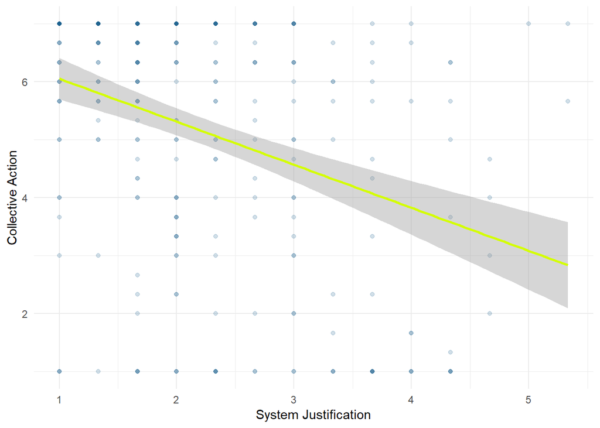

Figure 9. Relationship between System Justification and Collective Action with linear fit.

```r
ggplot(my_data, aes(SJ, CA)) + geom_point(color=color, alpha=.2) +
                                 xlab('System Justification') +
                                 ylab('Collective Action') +
                                 geom_smooth(color=color2, method='lm') +
                                 theme_minimal()
```

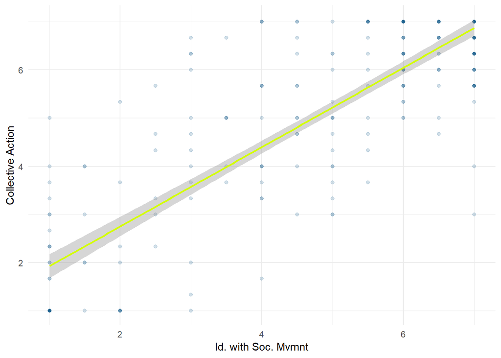

Figure 10. Relationship between Identification with Social Movement and Collective Action with linear fit.

```r
ggplot(my_data, aes(ID, CA)) + geom_point(color=color, alpha=.2) +
                                 xlab('Id. with Soc. Mvmnt') +
                                 ylab('Collective Action') +
                                 geom_smooth(color=color2, method='lm') +
                                 theme_minimal()
```

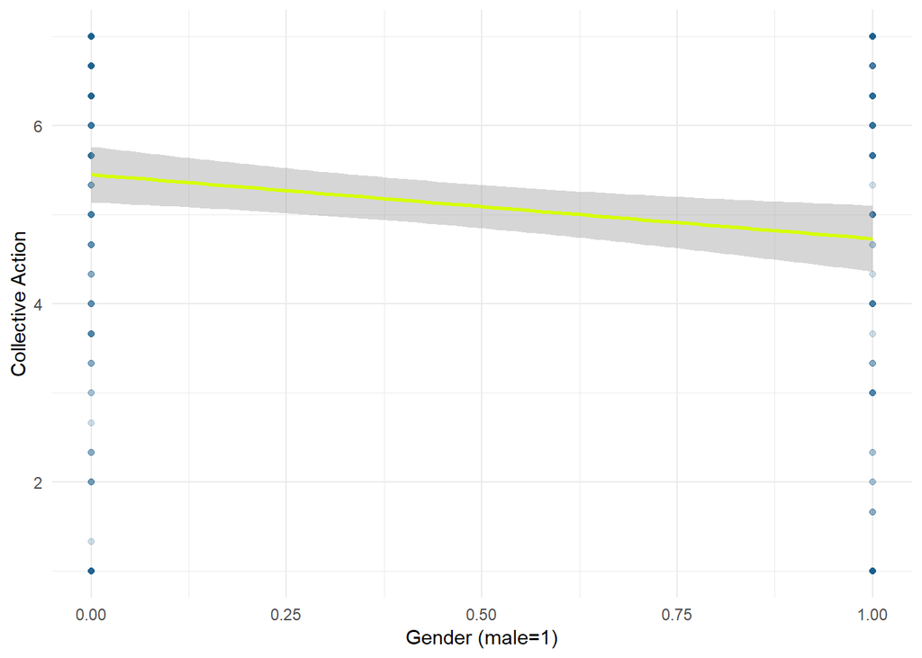

Figure 11. Relationship between Gender and Collective Action with linear fit.

```r
ggplot(my_data, aes(gender_recode, CA)) + geom_point(color=color, alpha=.2) +
                                 xlab('Gender (male=1)') +
                                 ylab('Collective Action') +
                                 geom_smooth(color=color2, method='lm') +
                                 theme_minimal()
```

### Diagnose Model 3. Using appropriate statistics:

##### Check if the model suffers from multicollinearity

```r
vif(model_3a)
```

```
##            SJ            ID gender_recode
##      1.144305      1.129336      1.026776
```

Values of variance inflation factor are low (<<10) in `model_3a`. Also $\mu(VIF)<5$.

Model does not suffer from multicollinearity.

##### Check if the independence condition is met

```r
durbinWatsonTest(model_3a)
```

```
##  lag Autocorrelation D-W Statistic p-value
##    1       0.2043503      1.576914       0
##  Alternative hypothesis: rho != 0
```

$D-W$ statistic is significant ($p\approx 0$). This suggests that errors in `model_3a` are autocorrelated at lag 1 and therefore the assumption of independence is not met.

Nonetheless Field (2009) suggests that values under 1 or more than 3 are a cause for concern. According to his criteria `model_3a` does not violate assumption of independence as $D-W = 1.58$.

##### Check if the proportion of large standardized residuals (>2) is acceptable

```r
# Get std residuals
std_res <- rstandard(model_3a)

# Compute freq
hi_std_res <- std_res > 2 | std_res < -2

sum(hi_std_res) / length(std_res)
```

```
## [1] 0.07508532
```

There’s $7.5$% of large standardized residuals, which exceeds the conventional threshold of $5$%.

##### Check if there are any influential observations, as suggested by Cook’s distance

```r
# Save Cook's distances
cooks <- cooks.distance(model_3a)

# Compute frequency of Cook's dist.
sum(cooks>1)
```

```
## [1] 0
```

As propsed by Cook and Weisberg (1982) influeantial observations should have $D_i > 1$. There are no such observations in `model_3a`.

Based on this observation we can say that there are no influential cases in `model_3a`.

##### Check if the model is correctly specified based on residuals’ plots

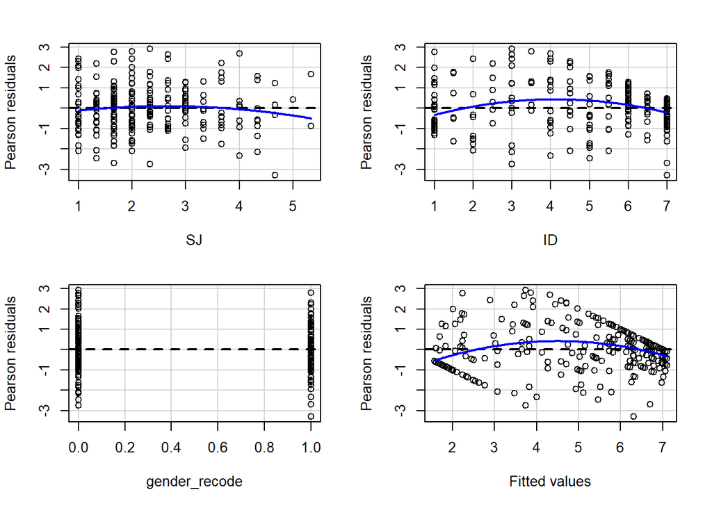

```
##               Test stat Pr(>|Test stat|)
## SJ              -1.6124            0.108
## ID              -4.6241        5.688e-06 ***
## gender_recode   -0.3535            0.724
## Tukey test      -4.7225        2.330e-06 ***
## ---
## Signif. codes:  0 '***' 0.001 '**' 0.01 '*' 0.05 '.' 0.1 ' ' 1
```

```r
residualPlots(model_3a)
```

Above plots may suggest non-linearity in the data, yet it seems not very strong.

Adding non-linear data transformation could improve model fit.

### Report the results of Models 1-3 in a tabular form in accordance with APA guidelines (Table 5.12, p. 144).

```r
stargazer(model_1, model_2, model_3a,
          header=FALSE,
          type='html',
          align=TRUE,
          title="Table 1. Comparison of models (Model 1, Model 2, Model 3)",
          covariate.labels=c("System Justification", "Identification w/ Social Movement", "Gender"),
          dep.var.labels="Collective Action")
```

**Table 1. Comparison of models (Model 1, Model 2, Model 3)**

|  | *Dependent variable:* |  |  |
| --- | --- | --- | --- |
|  | Collective Action |  |  |
|  | (1) | (2) | (3) |
| System Justification | -0.742*** | -0.152** | -0.132** |
|  | (0.115) | (0.065) | (0.065) |
| Identification w/ Social Movement |  | 0.800*** | 0.796*** |
|  |  | (0.029) | (0.029) |
| Gender |  |  | -0.315** |
|  |  |  | (0.125) |
| Constant | 6.796*** | 1.556*** | 1.661*** |
|  | (0.279) | (0.243) | (0.245) |
| Observations | 293 | 293 | 293 |
| R<sup>2</sup> | 0.125 | 0.753 | 0.759 |
| Adjusted R<sup>2</sup> | 0.122 | 0.752 | 0.756 |
| Residual Std. Error | 1.970 (df = 291) | 1.048 (df = 290) | 1.038 (df = 289) |
| F Statistic | 41.690*** (df = 1; 291) | 443.054*** (df = 2; 290) | 302.994*** (df = 3; 289) |
| *Note:* | p<0.1; p<0.05; p<0.01 |  |  |

### The residualPlots() function produces the results of Tukey test.

##### What is the H0 specific to this test?

$H_0$ for this test says that coefficient of quadratic term added to the model equals $0$.

In other words, model is additive.

##### What does the result obtained for Model 3 tell us?

The result obtained for `model_3a` ($p<.001$) tells us that quadratic term for $ID$ is not equal to $0$ and model is not strictly additive (Tukey test significant, $p\approx 0$).

##### Does changing the model in accordance with Tukey test improve the fit? (hint: if you want to add a quadratic term for variable x to regression model, you can do it by adding I(x^2) to regression equation code).

```r
model_4 <- lm(CA ~ SJ + ID + gender_recode + I(ID^2), my_data)
```

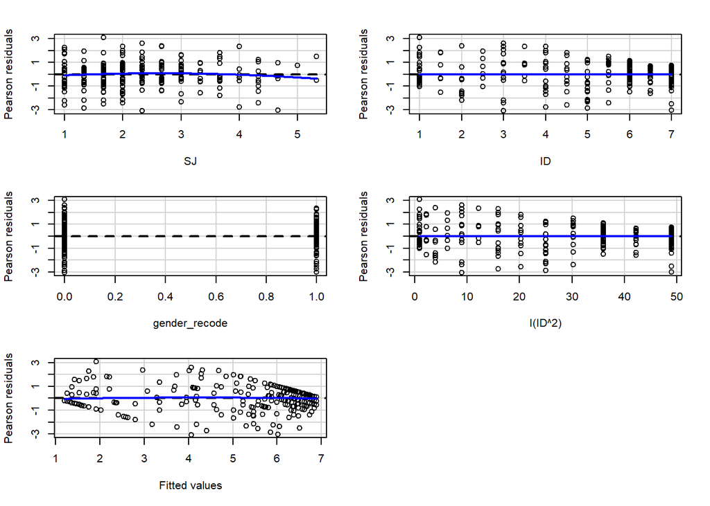

```
##               Test stat Pr(>|Test stat|)
## SJ              -1.2494           0.2126
## ID              -1.3701           0.1717
## gender_recode   -0.7065           0.4805
## I(ID^2)          0.0578           0.9539
## Tukey test      -1.1477           0.2511
```

```r
residualPlots(model_4)
```

Adding a quadratic transformation of $ID$ improves the fit.

Tukey’s test becomes insignificant, suggesting good fit of the model.

##### What does the new model tell us about the relationships between predictors and the DV?

It tells us that identification with social movement has non-linear relationship with $CA$.

## Modelling 2: Logistic Regression

### Now, let’s move to explaining respondents’ actual participation.

##### Regress participation on system justification (Model 1).

```r
# Recode `behaviour` to 1s and 0s
my_data$behav_recode <- as.numeric(my_data$behaviour) - 1
```

```r
logreg_1 <- glm(behav_recode ~ SJ, my_data, family='binomial')
```

##### Provide confidence intervals, system justification odds ratio and confidence intervals for odds ratio.

```r
# Summary
summary(logreg_1)
```

```
##
## Call:
## glm(formula = behav_recode ~ SJ, family = "binomial", data = my_data)
##
## Deviance Residuals:
##     Min       1Q   Median       3Q      Max
## -1.7227  -1.2472   0.7749   0.9000   1.6560
##
## Coefficients:
##             Estimate Std. Error z value Pr(>|z|)
## (Intercept)   1.7586     0.3170   5.547 2.91e-08 ***
## SJ           -0.5319     0.1265  -4.205 2.61e-05 ***
## ---
## Signif. codes:  0 '***' 0.001 '**' 0.01 '*' 0.05 '.' 0.1 ' ' 1
##
## (Dispersion parameter for binomial family taken to be 1)
##
##     Null deviance: 384.62  on 292  degrees of freedom
## Residual deviance: 365.80  on 291  degrees of freedom
## AIC: 369.8
##
## Number of Fisher Scoring iterations: 4
```

```r
# Conf ints
confint(logreg_1)
```

```
##                  2.5 %     97.5 %
## (Intercept)  1.1507600  2.3963588
## SJ          -0.7859218 -0.2884514
```

```r
# Get odds ratios
exp(logreg_1$coefficients)
```

```
## (Intercept)          SJ
##   5.8040920   0.5874629
```

##### Interpret the odds ratio.

Odds ratio of $.59$ means that $SJ$ is related to decreased probability of participation in Equality Parade. According to McHugh (2009) odds ratios $<1$ are not directly interpretable.

##### Is this model better than the null model?

```r
lrtest(logreg_1)
```

```
## Likelihood ratio test
##
## Model 1: behav_recode ~ SJ
## Model 2: behav_recode ~ 1
##   #Df  LogLik Df Chisq Pr(>Chisq)
## 1   2 -182.90
## 2   1 -192.31 -1 18.82  1.437e-05 ***
## ---
## Signif. codes:  0 '***' 0.001 '**' 0.01 '*' 0.05 '.' 0.1 ' ' 1
```

Yes.

##### How do you know it?

Deviance of `logreg_1` ($D=365.8$) is lower than null model’s deviance ($D=384.62$).

This difference is significant, $p<.001$

##### Provide pseudo-R2 for this model.

```r
nagelkerke(logreg_1)
```

```
## $Models
##
## Model: "glm, behav_recode ~ SJ, binomial, my_data"
## Null:  "glm, behav_recode ~ 1, binomial, my_data"
##
## $Pseudo.R.squared.for.model.vs.null
##                              Pseudo.R.squared
## McFadden                            0.0489304
## Cox and Snell (ML)                  0.0622112
## Nagelkerke (Cragg and Uhler)        0.0851153
##
## $Likelihood.ratio.test
##  Df.diff LogLik.diff Chisq    p.value
##       -1     -9.4098 18.82 1.4369e-05
##
## $Number.of.observations
##
## Model: 293
## Null:  293
##
## $Messages
## [1] "Note: For models fit with REML, these statistics are based on refitting with ML"
##
## $Warnings
## [1] "None"
```

Nagelkerke’s $pseudo-R^2$ equals $.085$

##### Visualise the relationship between system justification and the probability of participation.

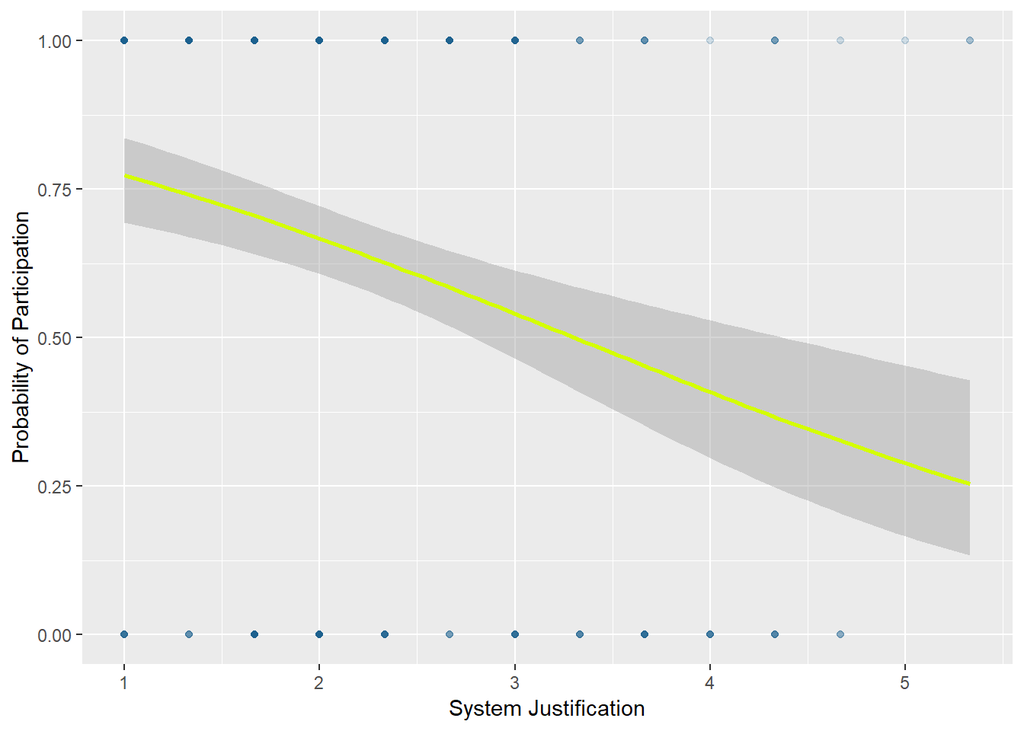

Figure 12. Relationship between System Justification and Probability of Participation in Equality Parade.

```r
my_data %>%
  ggplot(aes(SJ, behav_recode)) +
  geom_point(alpha = .2, color=color) +
  geom_smooth(method = "glm", method.args = list(family = "binomial"), color=color2) +
  xlab("System Justification") +
  ylab("Probability of Participation")
```

### Add identification with the social movement and gender as the predictors (Model 2).

```r
logreg_2 <- glm(behav_recode ~ SJ + ID + gender_recode, my_data, family='binomial')
```

##### Does this model fit data better than Model 1? Provide the appropriate statistic and pvalue.

```r
lrtest(logreg_1, logreg_2)
```

```
## Likelihood ratio test
##
## Model 1: behav_recode ~ SJ
## Model 2: behav_recode ~ SJ + ID + gender_recode
##   #Df  LogLik Df  Chisq Pr(>Chisq)
## 1   2 -182.90
## 2   4  -81.33  2 203.14  < 2.2e-16 ***
## ---
## Signif. codes:  0 '***' 0.001 '**' 0.01 '*' 0.05 '.' 0.1 ' ' 1
```

`logreg_2` fits data better than `logreg_1`.

Model 2 (`logreg_2`) has lower deviance ($D=162.66$) than `logreg_1` ($D=365.8$) and this difference is significant at $p<.001$.

##### Provide confidence intervals, odds ratios and confidence intervals for odds ratios for the regression coefficients.

```r
# Conf int
confint(logreg_2)
```

```
##                    2.5 %     97.5 %
## (Intercept)   -8.0024222 -4.0604867
## SJ            -0.3848841  0.4654267
## ID             1.0208143  1.5958905
## gender_recode -0.1567813  1.5756391
```

```r
# Odds ratio
exp(logreg_2$coefficients)
```

```
##   (Intercept)            SJ            ID gender_recode
##   0.002813169   1.032321564   3.604111616   1.981708051
```

```r
# Conf ints for OR
exp(confint(logreg_2))
```

```
##                     2.5 %     97.5 %
## (Intercept)   0.000334651 0.01724063
## SJ            0.680529502 1.59269372
## ID            2.775453924 4.93271988
## gender_recode 0.854891002 4.83382982
```

##### Interpret the odds ratios.

With increase of one unit in $SJ$ odds to participate in Equality Parade increase by a factor of $1.03$.

With increase of one unit in $ID$ odds to participate in Equality Parade increase by a factor of $3.604$.

### Based on Model 2, what is the probability of participation for:

##### a woman (gender = “female”) whose system justification = 7 and identification with the social movement = 1?

```r
predict(logreg_2, data.frame(SJ = 7, ID = 1, gender_recode=0), type='response')
```

```
##          1
## 0.01250927
```

##### a woman (gender = “female”) whose system justification = 3 and identification with the social movement = 4?

```r
predict(logreg_2, data.frame(SJ = 3, ID = 4, gender_recode=0), type='response')
```

```
##         1
## 0.3430545
```

## Modelling 3: Poisson Regression

### visualise the distribution of EMB1.

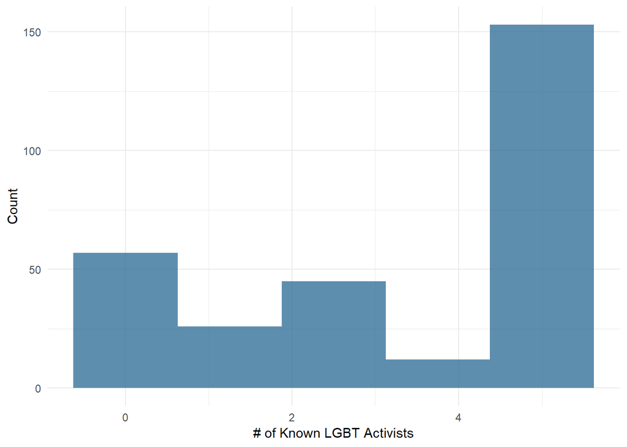

Figure 13. Histogram: # of Known LGBT Activists.

```r
# Histogrm: System Justification
ggplot(my_data, aes(EMB1)) + geom_histogram(bins=5, fill=color, alpha=.7) +
                           xlab('# of Known LGBT Activists') +
                           ylab('Count') +
                           theme_minimal()
```

##### Is it consistent with Poisson distribution? Perform an appropriate test.

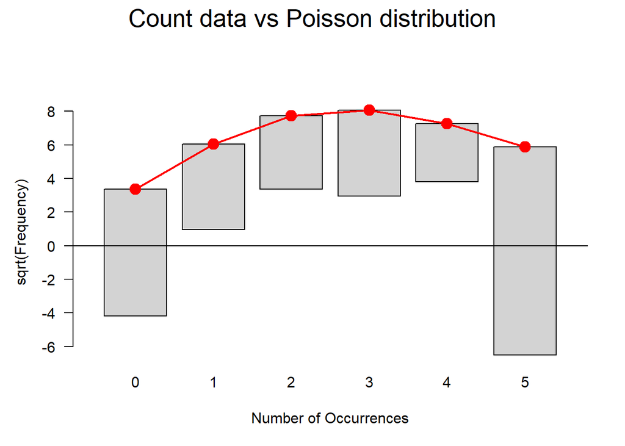

```r
gf = goodfit(my_data$EMB1,type= "poisson",method= "ML")
plot(gf,main="Count data vs Poisson distribution")
```

```r
summary(gf)
```

```
##
##   Goodness-of-fit test for poisson distribution
##
##                       X^2 df      P(> X^2)
## Likelihood Ratio 496.0271  4 4.845257e-106
```

Low p-value ($p\approx 0$) suggests that the distribution of $EMB1$ does not follow Poisson distribution.

##### If the distribution of EMB1 is consistent with Poisson distribution, regress it on system justification, identification with the social movement and gender.

##### Is the number of known activists related to any of these variables?

##### Provide the R2 for this model.

##### If the distribution of EMB1 is not consistent with Poisson distribution, do not perform any regression model

## References

- Cook, R. D., Weisberg, S. (1982). Residuals and Influence in Regression. New York: Chapman & Hall.
- Field, A.P. (2009). Discovering statistics using SPSS: and sex and drugs and rock ‘n’ roll (3rd edition). London: Sage.
- Hastie, T., Tibshirani, R., & Friedman, J. H. (2009). The elements of statistical learning: data mining, inference, and prediction. 2nd ed. New York: Springer.
- McHugh, M. L. (2009). The odds ratio: calculation, usage and interpretation. Lessons in biostatistics 19(2).